# Practical Machine Learning March 2015

Peter Hahn

March 2015

## Source .rmd

available at: https://github.com/phahn57/Coursera-PML

## Introduction

Analysis of data obtained from moving sensors have to be analysed. Several people were asked to lift a dumbbell in one correct and four incorrect fashion. exactly according to the specification (Class A), throwing the elbows to the front (Class B), lifting the dumbbell only halfway (Class C), lowering the dumbbell only halfway (Class D) and throwing the hips to the front (Class E).

Using machine learning a model should be fitted to the data, whih can be used to predict kind of movement(A-E) from the measurements of sensors.

Read more: http://groupware.les.inf.puc-rio.br/har#ixzz3TRXwiS6M

## Data loading and exploratory data analysis.

**Data are obtained from: link http://groupware.les.inf.puc-rio.br/har (weightlifting)**

**Thanks for the genourosity of the researchers which allowed their data to be used for this assignment**

## After this basic analysis, predictors are presented graphically

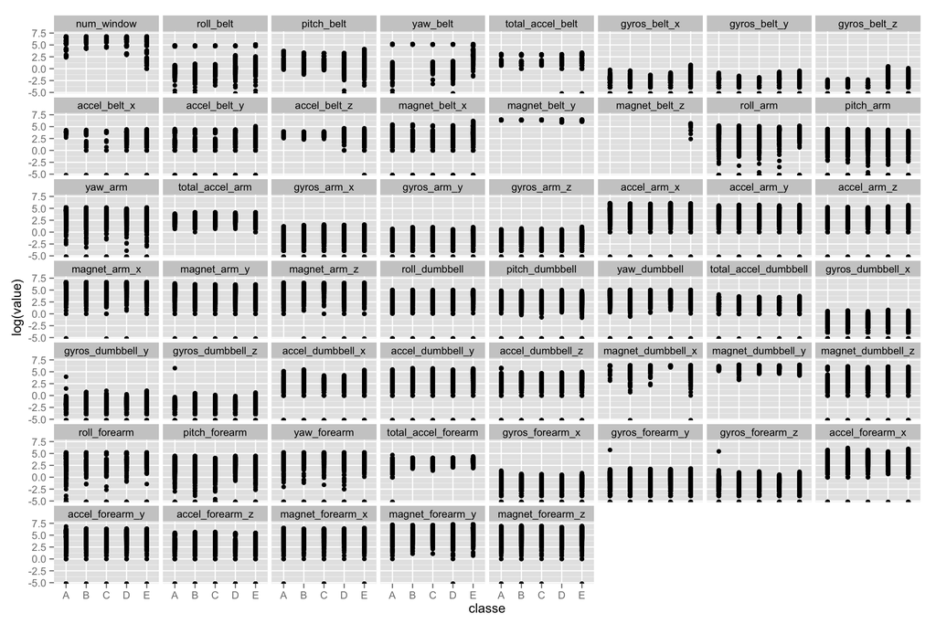

There are now remaining predictors with zero values or with appearently outliers. ## Removing near zero values and highly correlated predictors As by optical recognition data seem to be tidy, further statistical preprocessing is done. As analyses of near zero values gave no additional information, they are omitted here. 20 columns are excluded because they show high correlation to other variables

## Training and testing

Training data set is split into 2 parts 70-30. One part for model-building. The other part for model testing. This splitting is used later for in and out of sample error calculation.

## First model calculation

```
## Random Forest
##
## 13737 samples
##    33 predictor
##     5 classes: 'A', 'B', 'C', 'D', 'E'
##
## No pre-processing
## Resampling: Cross-Validated (3 fold)
##
## Summary of sample sizes: 9157, 9159, 9158
##
## Resampling results
##
##   Accuracy   Kappa      Accuracy SD   Kappa SD
##   0.9951227  0.9938302  0.0009840628  0.001245289
##
## Tuning parameter 'mtry' was held constant at a value of 5
##
```

## Testing against test-set builded from the training set

```
##
## pred    A    B    C    D    E
##    A 1674    0    0    0    0
##    B    0 1139    2    0    0
##    C    0    0 1023    5    0
##    D    0    0    1  958    3
##    E    0    0    0    1 1079
```

## Cross validation

Although random forrest perform an internal cross validation another prediction model is tested, using gbm (Generalized Boosted Regression Modelling)

```
## Stochastic Gradient Boosting
##
## 13737 samples
##    33 predictor
##     5 classes: 'A', 'B', 'C', 'D', 'E'
##
## No pre-processing
## Resampling: Bootstrapped (25 reps)
##
## Summary of sample sizes: 13737, 13737, 13737, 13737, 13737, 13737, ...
##
## Resampling results across tuning parameters:
##
##   interaction.depth  n.trees  Accuracy   Kappa      Accuracy SD
##   1                   50      0.7211823  0.6462255  0.005207587
##   1                  100      0.7948754  0.7402686  0.005108837
##   1                  150      0.8390742  0.7963067  0.005001429
##   2                   50      0.8688770  0.8339742  0.005121846
##   2                  100      0.9313885  0.9131902  0.004624306
##   2                  150      0.9596452  0.9489459  0.003492812
##   3                   50      0.9280150  0.9089002  0.004082928
##   3                  100      0.9716466  0.9641289  0.003254974
##   3                  150      0.9870459  0.9836135  0.002303141
##   Kappa SD
##   0.006677258
##   0.006476259
##   0.006385730
##   0.006494694
##   0.005832675
##   0.004394108
##   0.005182214
##   0.004115047
##   0.002908605
##
## Tuning parameter 'shrinkage' was held constant at a value of 0.1
## Accuracy was used to select the optimal model using  the largest value.
## The final values used for the model were n.trees = 150,
##  interaction.depth = 3 and shrinkage = 0.1.
```

## Testing against test-set builded from the training set

```
##
## pred1    A    B    C    D    E
##     A 1672    6    0    0    0
##     B    2 1129   11    5    0
##     C    0    3 1012    9    0
##     D    0    0    3  949   10
##     E    0    1    0    1 1072
```

## Out of sample error and accuracy

Random forest approach gives an accuracy of 0.9979609 and the GBM approach of 0.9913339 Thus Random forrest seems to give better results.

## For calculation of sample error the random forest model is used.

I expect the out- of sample error to be greater than the in- of sample error.

The **in sample error** is 0 as demonstrated in the following table, comparing prediction of training data versus training.

**Out of sample error** is greater ( approx. 0.2%) which can be calculated from the second table below. This errors are already “smoothened” by the cross validation process used in the above calculations.

```
##
## predtrain    A    B    C    D    E
##         A 3906    0    0    0    0
##         B    0 2658    0    0    0
##         C    0    0 2396    0    0
##         D    0    0    0 2252    0
##         E    0    0    0    0 2525
```

```
##
## predtest    A    B    C    D    E
##        A 1674    0    0    0    0
##        B    0 1139    2    0    0
##        C    0    0 1023    5    0
##        D    0    0    1  958    3
##        E    0    0    0    1 1079
```

## Result

Using both approaches for prediction of the test-data provided with the assignment gave the same results. The results were uploaded to the submission page and gave 20 points out of 20